# Package_Week2

Jiyeon

### **문제 0번**

```r
library(MLmetrics)
library(tidyverse)
library(data.table)
library(gridExtra)
library(lubridate)
library(caret)
library(progress)

setwd("C:/Users/user/Desktop/Package_Week2")


data <- fread("train.csv",
              header = T,
              stringsAsFactors = F,
              data.table = F,
              encoding = "UTF-8")

test <- fread("test.csv",
              header = T,
              stringsAsFactors = F,
              data.table = F,
              encoding = "UTF-8")

data <- data %>% mutate_at(vars(YEAR, MONTH, FLC, SEX_CTGO_CD), as.character)

test <- test %>% mutate(YEAR = substr(REG_YYMM, start = 1, stop = 4),
                        MONTH = substr(REG_YYMM, start = 5, stop = 6)) %>%
  select(-c(REG_YYMM, CARD_SIDO_NM)) %>%
  mutate_at(vars(YEAR, MONTH, FLC, SEX_CTGO_CD), as.character)
```

### **문제 1번 : 새로 등장한 factor 확인**

#### **1-1 새롭게 등장한 factor level 변수별로 확인**

```r
# factor형 변수로 바꿔주기
data <- data %>% mutate_at(vars(CARD_CCG_NM, STD_CLSS_NM, HOM_SIDO_NM, HOM_CCG_NM, AGE, SEX_CTGO_CD, FLC, YEAR, MONTH),as.factor)
test <- test %>% mutate_at(vars(CARD_CCG_NM, STD_CLSS_NM, HOM_SIDO_NM, HOM_CCG_NM, AGE, SEX_CTGO_CD, FLC, YEAR, MONTH),as.factor)

# test엔 있는데 train에는 없는 factor level 확인하기
levels(test$CARD_CCG_NM) == levels(data$CARD_CCG_NM)
```

```
##  [1] TRUE TRUE TRUE TRUE TRUE TRUE TRUE TRUE TRUE TRUE TRUE TRUE TRUE TRUE TRUE
## [16] TRUE TRUE TRUE TRUE TRUE TRUE TRUE TRUE TRUE TRUE
```

- `==` 을 사용하면 test와 data의 factor 변수의 level 하나하나가 같은지 아닌지 확인할 수 있다.
- 이 경우 모든 level 이 일치한다는 뜻이지만 우리가 지금 알고 싶은 것은 아님.

```r
levels(test$CARD_CCG_NM) %in% levels(data$CARD_CCG_NM)
```

```
##  [1] TRUE TRUE TRUE TRUE TRUE TRUE TRUE TRUE TRUE TRUE TRUE TRUE TRUE TRUE TRUE
## [16] TRUE TRUE TRUE TRUE TRUE TRUE TRUE TRUE TRUE TRUE
```

- `%in%` 를 사용하면 test의 factor level이 data의 facor level 안에 들어있는지 확인 가능하다.
- 우리가 알고싶은 경우! 하지만 정확히는 FALSE 의 개수가 알고 싶음...(안들어가는 경우를 알고싶은 거니까)

```r
sum(!levels(test$CARD_CCG_NM) %in% levels(data$CARD_CCG_NM))
```

```
## [1] 0
```

`!`를 앞에 붙여줘서 TRUE와 FALSE 반환값을 바꿔서 합해주면 FALSE 개수를 셀 수 있다.

```r
for(i in 1:9){
  data_fact = data %>% select_if(is.factor)
  test_fact = test %>% select_if(is.factor)
  count = sum(!(levels(test_fact[,i]) %in% levels(data_fact[,i]))) #FALSE 개수
  if(count == 0){
    cat(colnames(test_fact)[i], "변수에 test에만 있는 factor level은 없다.", "\n")
  }else{
    cat(colnames(test_fact)[i], "변수에서 test에만 있는 factor level은 ",setdiff(levels(test_fact[,i]), levels(data_fact)), "로", count, "개 이다.", "\n")
  }
}
```

```
## CARD_CCG_NM 변수에 test에만 있는 factor level은 없다.
## STD_CLSS_NM 변수에 test에만 있는 factor level은 없다.
## HOM_SIDO_NM 변수에 test에만 있는 factor level은 없다.
## HOM_CCG_NM 변수에 test에만 있는 factor level은 없다.
## AGE 변수에 test에만 있는 factor level은 없다.
## SEX_CTGO_CD 변수에 test에만 있는 factor level은 없다.
## FLC 변수에 test에만 있는 factor level은 없다.
## YEAR 변수에 test에만 있는 factor level은 없다.
## MONTH 변수에서 test에만 있는 factor level은  03 로 1 개 이다.
```

```r
levels(data$MONTH)
```

```
## [1] "1"  "11" "12" "2"
```

```r
levels(test$MONTH) #test의 MONTH 변수는 모두 3월
```

```
## [1] "03"
```

#### **1-2 시각화**

```r
newlevel_df <- data.frame(var = colnames(test %>% select_if(is.factor)), newlevel = NA)

for(i in 1:9){
  data_fact = data %>% select_if(is.factor)
  test_fact = test %>% select_if(is.factor)
  newlevel_df[i,"newlevel"] = sum(!(levels(test_fact[,i]) %in% levels(data_fact[,i])))
}

newlevel_df
```

```
##           var newlevel
## 1 CARD_CCG_NM        0
## 2 STD_CLSS_NM        0
## 3 HOM_SIDO_NM        0
## 4  HOM_CCG_NM        0
## 5         AGE        0
## 6 SEX_CTGO_CD        0
## 7         FLC        0
## 8        YEAR        0
## 9       MONTH        1
```

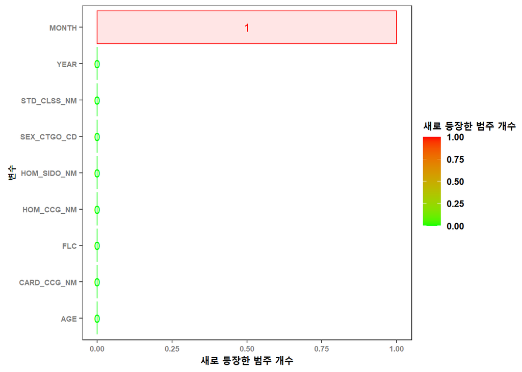

```r
ggplot(newlevel_df, aes(x = newlevel, y = reorder(var, newlevel))) +
  geom_col(aes(fill = newlevel, color = newlevel), alpha = .1) +
  geom_text(aes(label = newlevel, color = newlevel), position = position_stack(vjust = .5)) +
  scale_fill_gradient(low = "green", high = "red", aesthetics = c("color", "fill")) +
  labs(x = "새로 등장한 범주 개수", y = "변수", fill = "새로 등장한 범주 개수" ) +
  guides(color = FALSE) +
  theme_test() +
  theme(axis.title = element_text(face = "bold"),
        axis.text = element_text(face = "bold", color = "grey50", size = 7),
        legend.title = element_text(face ="bold"),
        legend.text = element_text(face = "bold"))
```

#### **1-3 일반 회귀모델링을 할 경우 어떤 문제가 생기나? + 해결 방법**

- 범주형 독립변수는 회귀모형에서 0 또는 1의 값을 갖는 dummy variable의 형태로 들어가는데, MONTH 변수처럼 기존에 모형을 만들 때 쓰인 데이터(이 경우 data)의 범주형 독립변수에는 없던 level이 newdata(이 경우 test) 에 존재하면 그 level에 대한 종속변수를 예측할 수 없게 된다.
- 이러한 문제는 회귀모형을 돌릴 때 사용한 데이터의 범주형 독립변수에 미리 새로운 level 까지 포함해주거나, 회귀모형을 만들 때 문제의 범주형 변수를 제외해주면 해결할 수 있다.

#### **1-4**

```r
data = data %>% select(-MONTH)
test = test %>% select(-MONTH)
rm(list = ls()[which(ls() != "data")])
```

### **문제 2번 Hold out & K-fold CV**

#### **2-1 'AMT'를 제외한 변수 3개 조합**

```r
combi <- gtools::combinations(11,3, colnames(data[-10])) #'AMT' 제외한 변수 3개 조합 생성
head(combi, 20)
```

```
##       [,1]  [,2]          [,3]
##  [1,] "AGE" "AGE_N"       "CARD_CCG_NM"
##  [2,] "AGE" "AGE_N"       "CNT"
##  [3,] "AGE" "AGE_N"       "CSTMR_CNT"
##  [4,] "AGE" "AGE_N"       "FLC"
##  [5,] "AGE" "AGE_N"       "HOM_CCG_NM"
##  [6,] "AGE" "AGE_N"       "HOM_SIDO_NM"
##  [7,] "AGE" "AGE_N"       "SEX_CTGO_CD"
##  [8,] "AGE" "AGE_N"       "STD_CLSS_NM"
##  [9,] "AGE" "AGE_N"       "YEAR"
## [10,] "AGE" "CARD_CCG_NM" "CNT"
## [11,] "AGE" "CARD_CCG_NM" "CSTMR_CNT"
## [12,] "AGE" "CARD_CCG_NM" "FLC"
## [13,] "AGE" "CARD_CCG_NM" "HOM_CCG_NM"
## [14,] "AGE" "CARD_CCG_NM" "HOM_SIDO_NM"
## [15,] "AGE" "CARD_CCG_NM" "SEX_CTGO_CD"
## [16,] "AGE" "CARD_CCG_NM" "STD_CLSS_NM"
## [17,] "AGE" "CARD_CCG_NM" "YEAR"
## [18,] "AGE" "CNT"         "CSTMR_CNT"
## [19,] "AGE" "CNT"         "FLC"
## [20,] "AGE" "CNT"         "HOM_CCG_NM"
```

#### **2-2 Hold out method**

**2-2-1**

```r
hold_out <- data.frame(variable = rep(NA,165), RMSE = NA)
```

**2-2-2 data 7:3 비율로 나누기**

```r
set.seed(1234)
part <- createDataPartition(data$AMT,p=0.3) # 층화 추출로 데이터 분할
dat_tr <- data[-part$Resample1,]
dat_te <- data[part$Resample1,]
nrow(dat_te)/nrow(data) #7:3으로 잘 나눠졌는지 확인!
```

```
## [1] 0.300017
```

**2-2-3 RMSE 계산**

```r
pb <- progress_bar$new(total = 165)

for(i in 1:165){
  hold_out[i, "variable"] = paste("Combination_", i)
  fit = lm(AMT ~ ., data = dat_tr %>% select(-combi[i,]))
  pred = predict(fit, dat_te)
  hold_out[i,"RMSE"] = round(RMSE(dat_te$AMT, pred), 2)
  pb$tick()
  Sys.sleep(0.01)
}

head(hold_out, 20) # 너무 기니까 20개만
```

```
##           variable     RMSE
## 1   Combination_ 1  8584627
## 2   Combination_ 2  8557117
## 3   Combination_ 3  9888995
## 4   Combination_ 4  8607818
## 5   Combination_ 5  8584404
## 6   Combination_ 6  8581739
## 7   Combination_ 7  8582827
## 8   Combination_ 8  8787045
## 9   Combination_ 9  8581844
## 10 Combination_ 10  8559461
## 11 Combination_ 11  9891017
## 12 Combination_ 12  8587647
## 13 Combination_ 13  8586587
## 14 Combination_ 14  8583810
## 15 Combination_ 15  8584768
## 16 Combination_ 16  8794335
## 17 Combination_ 17  8583926
## 18 Combination_ 18 16185642
## 19 Combination_ 19  8560045
## 20 Combination_ 20  8558552
```

#### **2-3 5-fold CV method**

**2-3-1**

```r
kfold_cv <- data.frame(variable = rep(NA, 165), RMSE = NA)
```

**2-3-2 RMSE 계산**

```r
pb <- progress_bar$new(total = 165*5)

set.seed(1234)
cv <-  createFolds(data$AMT, k = 5) # 5 fold CV로 분할

for(i in 1:165){
  kfold_cv[i, "variable"] = paste("Combination_", i)
  cverror = NULL
  combidata = data %>% select(-combi[i,])
  for(k in 1:5){
    index = cv[[k]]
    dat_tr = combidata[-index, ]
    dat_te = combidata[index, ]
    fit = lm(AMT~., dat_tr)
    pred = predict(fit, dat_te)
    cverror[k] = RMSE(dat_te$AMT, pred)
  }
  kfold_cv[i,"RMSE"] = round(mean(cverror), 2)

  pb$tick()
  Sys.sleep(0.01)
}

head(kfold_cv, 20)
```

```
##           variable     RMSE
## 1   Combination_ 1  7744198
## 2   Combination_ 2  7742042
## 3   Combination_ 3  9037107
## 4   Combination_ 4  7761507
## 5   Combination_ 5  7742858
## 6   Combination_ 6  7738813
## 7   Combination_ 7  7740939
## 8   Combination_ 8  7970703
## 9   Combination_ 9  7738913
## 10 Combination_ 10  7747371
## 11 Combination_ 11  9040600
## 12 Combination_ 12  7747016
## 13 Combination_ 13  7747677
## 14 Combination_ 14  7743721
## 15 Combination_ 15  7745792
## 16 Combination_ 16  7983978
## 17 Combination_ 17  7743840
## 18 Combination_ 18 15722349
## 19 Combination_ 19  7744850
## 20 Combination_ 20  7745861
```

#### **2-4 시각화**

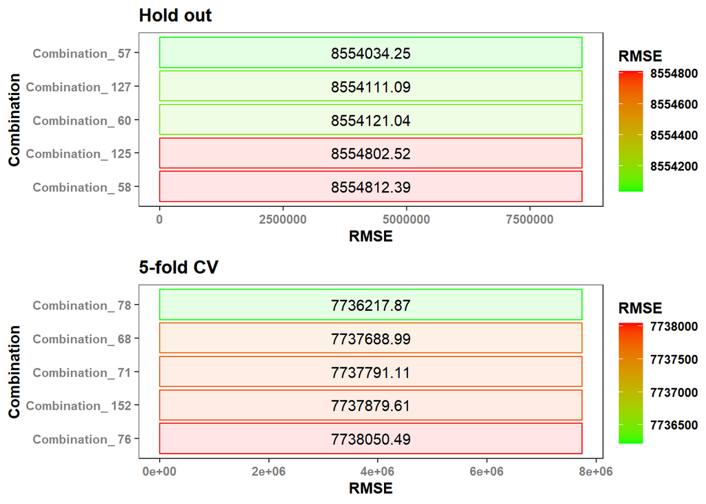

```r
p1 <- ggplot(hold_out %>% arrange(RMSE) %>% head(5), aes(x = RMSE, y = reorder(variable, -RMSE))) +
  geom_col(aes(fill = RMSE, color = RMSE), alpha = .1) +
  geom_text(aes(label = RMSE), position = position_stack(vjust = .5)) +
  scale_fill_gradient(low = "green", high = "red", aesthetics = c("color", "fill")) +
  labs(x = "RMSE", y = "Combination", fill = "RMSE", title = "Hold out") +
  guides(color = FALSE) +
  theme_test() +
  theme(axis.title = element_text(face = "bold"),
        axis.text = element_text(face = "bold", color = "grey50"),
        legend.title = element_text(face ="bold"),
        legend.text = element_text(face = "bold"),
        plot.title = element_text(face = "bold"))

p2 <- ggplot(kfold_cv %>% arrange(RMSE) %>% head(5), aes(x = RMSE, y = reorder(variable, -RMSE))) +
  geom_col(aes(fill = RMSE, color = RMSE), alpha = .1) +
  geom_text(aes(label = RMSE), position = position_stack(vjust = .5)) +
  scale_fill_gradient(low = "green", high = "red", aesthetics = c("color", "fill")) +
  labs(x = "RMSE", y = "Combination", fill = "RMSE", title = "5-fold CV") +
  guides(color = FALSE) +
  theme_test() +
  theme(axis.title = element_text(face = "bold"),
        axis.text = element_text(face = "bold", color = "grey50"),
        legend.title = element_text(face ="bold"),
        legend.text = element_text(face = "bold"),
        plot.title = element_text(face = "bold"))
grid.arrange(p1, p2, nrow =2)
```

#### **2-5**

```r
test <- fread("test.csv",
              header = T,
              stringsAsFactors = F,
              data.table = F,
              encoding = "UTF-8")
test <- test %>% mutate(YEAR = substr(REG_YYMM, start = 1, stop = 4),
                        MONTH = substr(REG_YYMM, start = 5, stop = 6)) %>%
  select(-c(REG_YYMM, CARD_SIDO_NM, MONTH)) %>%
  mutate_at(vars(YEAR, FLC, SEX_CTGO_CD), as.character)
```

#### **2-6 Hold-out method 와 5-fold CV method 각각에서 RMSE가 낮은 상위 5개 조합 제외하고 모델링 진행해서 test.csv 로 평가**

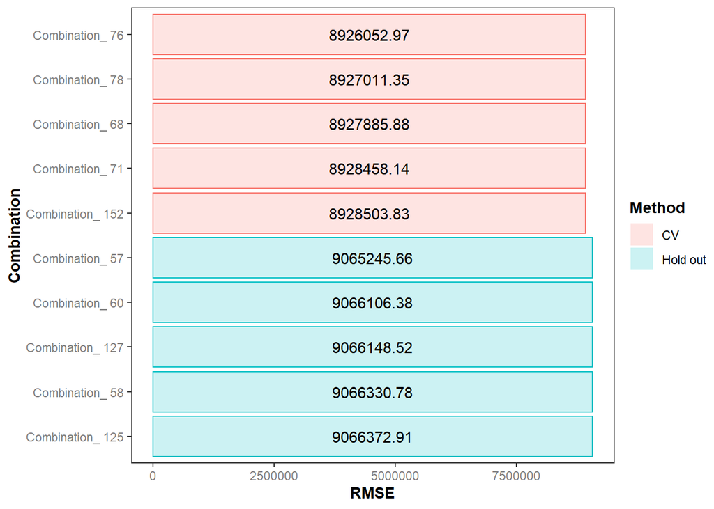

```r
df1 <- data.frame(variable = rep(NA, 5), RMSE = NA, method = "Hold out")
df2 <- data.frame(variable = rep(NA, 5), RMSE = NA, method = "CV")

for(i in 1:5){
  df1[i, "variable"] = paste("Combination_", order(hold_out$RMSE)[i])
  dat_tr = data %>% select(-combi[order(hold_out$RMSE)[i],])
  dat_te = test %>% select(-combi[order(hold_out$RMSE)[i],])
  fit = lm(AMT~., data = dat_tr)
  pred = predict(fit, dat_te)
  df1[i, "RMSE"] = round(RMSE(test$AMT, pred), 2)

  }
for(i in 1:5){
  df2[i, "variable"] = paste("Combination_", order(kfold_cv$RMSE)[i])
  dat_tr = data %>% select(-combi[order(kfold_cv$RMSE)[i],])
  dat_te = test %>% select(-combi[order(kfold_cv$RMSE)[i],])
  fit = lm(AMT~., data = dat_tr)
  pred = predict(fit,dat_te)
  df2[i, "RMSE"] = round(RMSE(test$AMT, pred), 2)
}

df <- rbind(df1, df2)

ggplot(data = df, aes(x = RMSE, y = reorder(variable, -RMSE), group = method)) +
  geom_col(aes(fill = method, color = method), alpha= .2) +
  geom_text(aes(label = RMSE), position = position_stack(vjust = .5)) +
  theme_test() +
  labs(x = "RMSE", y = "Combination", fill = "Method") +
  guides(color = FALSE) +
  theme(axis.title = element_text(face = "bold"),
        axis.text = element_text(color = "grey50"),
        legend.title = element_text(face ="bold"))
```

#### **2-7 결과 해석**

- 2-4는 Hold-out method 와 5-fold CV method로 모델을 평가해서 나온 rmse 값
- 2-6은 test set으로 모델을 평가해서 나온 rmse 값

결과를 해석해보자!

1. hold-out method로 모델을 평가했을 때보다 CV method로 모델을 평가했을 때 rmse 값이 더 낮다.
- *creteDataPartition 에서 p=0.7로 놓고 훈련데이터와 검증데이터를 거꾸로 분할 했을 때는 CV error 보다 hold-out 방법의 rmse가 더 좋게 나왔음*
- hold out 방법은 train set과 test set을 랜덤하게 분할하는데, 데이터가 어떻게 분할되는지에 따라 (어떤 관측치가 test set에 포함되는지에 따라) 모델을 평가할 때 나오는 error 값이 크게 변할 수 있다. 저번주 데마팀 클린업을 참고하면 hold-out error 가 cv error보다 큰 편차를 갖는다는 것을 알수 있음. *그래서 다른 방식으로 데이터 분할 했을 때 rmse가 더 좋게 나온 것도 납득 가능*
- 결국 모든 데이터를 여러 개의 fold로 나눠 각각의 validation set에 대한 mse 값을 평균 내서 error를 계산하는 **CV 방법이 더 안정적으로 test error를 따라간다.**
- 더불어 **Hold-out 방식은 모델을 적합할 때 쓰이는 train 데이터의 수가 더 적어지므로 모델 성능이 떨어질 수 밖에 없다.즉 표본사용의 효율성으로 봤을 때도 hold out보다 CV가 더 좋은 방법이다.**
2. 2-6 rmse 값이2-4의 rmse 값보다 높다. 즉, test error가 CV error나 Hold-out error보다 높다.
- Hold-out방식과 CV방식은 모델이 validation set에 대한 error를 최소화하는 방향으로 fit되기 때문에 일반적으로 test error보다 작은 값을 가진다. 이유는 모델의 하이퍼파라미터가 validation set에 적합하게 tuning 되기 때문인데 그러나 항상 그런 것은 아니고 일반적인 경우 그렇다.
- 그리고 보통 좋은 모델을 선택할 때는 train error와 validation error를 비교하거나 train error와 test error를 비교한다.